# Homework Demo 1: Explore Data about Countries

##### Benjamin Lin V624258 benjaminxianlin@gmail.com

# 1. Data Initialization

```python
%matplotlib inline
import numpy as np
import pandas as pd
import matplotlib.pyplot as plt
from mpl_toolkits.basemap import Basemap
from sklearn import linear_model #for linear regression
from sklearn.metrics import pairwise_distances
from scipy.spatial.distance import cosine
```

```python
def convert_to_deg(pos):
    direction = {"N":1, "S":-1, "E":1, "W":-1}
    if pos == "nan":
        return np.nan
    pos = pos.split()
    pos_direction = pos.pop()
    pos.extend([0,0])
    return (int(pos[0]) + int(pos[1])/60.0) * direction[pos_direction]
```

```python
#Tidy the data frame
df = pd.read_csv("country-data.csv", na_values=["unknown", "none"])
df["Latitude of Capital"] = df["Latitude of Capital"].astype(np.str)
df["Longitude of Capital"] = df["Longitude of Capital"].astype(np.str)
df["Latitude of Capital"] = df.apply(lambda row:convert_to_deg(row["Latitude of Capital"]), axis=1)
df["Longitude of Capital"] = df.apply(lambda row:convert_to_deg(row["Longitude of Capital"]), axis=1)
```

```python
#Make each col an array
country_name = np.array(df["Country Name"].values)
lat_of_cap = np.array(df["Latitude of Capital"].values).astype(np.float)
lon_of_cap = np.array(df["Longitude of Capital"].values).astype(np.float)
population = np.array(df["Population"].values).astype(np.int)
life_expectancy = np.array(df["Life Expectancy"].values).astype(np.float)
gdp = np.array(df["GDP (PPP) in US $"].values).astype(np.float)
gdp_per_capita = gdp / population
area = np.array(df["Area (sq km)"].values).astype(np.float)
land_boundary = np.array(df["Land Boundaries (km)"].values).astype(np.float)
coastline = np.array(df["Coastline (km)"].values).astype(np.float)
boundary = land_boundary + coastline
literacy_rate = np.array(df["Literacy Rate (%)"].values).astype(np.float)
health_exp_over_gdp = np.array(df["Health Expenditure/GDP"].values).astype(np.float)
military_exp_over_gdp = np.array(df["Military Expenditure/GDP"].values).astype(np.float)
water_resource = np.array(df["Renewable Water Resources (cu km)"].values).astype(np.float)
net_migration_rate = np.array(df["Net Migration Rate/1000 Population"].values).astype(np.float)
labor_force = np.array(df["Labor Force"].values).astype(np.float)
labor_force_rate = labor_force / population
internet_user = np.array(df["Internet Users (circa 2009)"].values).astype(np.float)
internet_user_rate = internet_user / population
commercial_prime_lending = np.array(df["Commercial Prime Lending Rate"].values).astype(np.float)
```

# 2. Plots

### 2.1 Scatter Plot

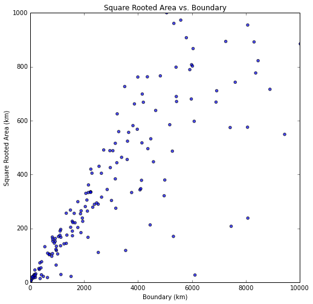

```python
sqrt_area = np.sqrt(np.array(area))

fig, ax = plt.subplots(1, 1, figsize=(8, 8))
ax.scatter(boundary, sqrt_area, alpha=0.7)
ax.set_xlabel('Boundary (km)')
ax.set_ylabel('Square Rooted Area (km)')
ax.set_title("Square Rooted Area vs. Boundary")
ax.set_xlim([0,10000])
ax.set_ylim([0,1000])
plt.show()
```

I hold an assumption that the shapes of most countries can be viewed as convex poligons. In other words, the increase of the perimeter of a shape leads to the increase of its area. From the scatter above, imagine you draw a straight line passing the most points. You will find the points lying on or above the line is much more than the points lying below the line. Therefore, it illustrates that area and boundary are postively related, which verifies my assumption.

### 2.2 Bar Chart

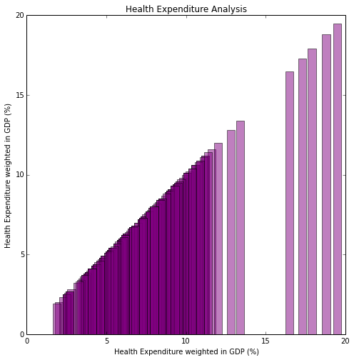

```python
fig, ax = plt.subplots(1, 1, figsize=(8, 8))
ax.bar(health_exp_over_gdp, health_exp_over_gdp, align="center", width=0.5, alpha=0.5, color='purple')
ax.set_xlabel('Health Expenditure weighted in GDP (%)')
ax.set_ylabel('Health Expenditure weighted in GDP (%)')
ax.set_title("Health Expenditure Analysis")
plt.show()
```

From the bar chart above, we can see that the majority of countries in the world have the percentage of health expenditure over GDP less than or equal to 12%. The United States, however, has 17.9% of its GDP spent on health expenditure. Based on my analysis, I think the U.S. government has spent too much of its income on health insurance. I would then suggest our next asministration to cut health insurance expenditure.

### 2.3 Pie Chart

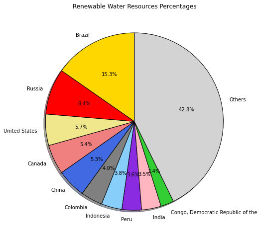

```python
water_country = df[["Country Name", "Renewable Water Resources (cu km)"]]
water_country = water_country.dropna(subset=["Renewable Water Resources (cu km)"])
water_country = water_country.sort_index(by=["Renewable Water Resources (cu km)"], ascending=False)

water_total = np.nansum(water_resource)

ctys = water_country["Country Name"][0:10]
ctys.loc[10] = "Others"

sizes = ((water_country["Renewable Water Resources (cu km)"][0:10]) / water_total)
sizes.loc[10] = 1 - sizes.sum()

colors = ["gold", "red", "khaki", "lightcoral", "royalblue", "gray",
          "lightskyblue", "blueviolet", "lightpink", "limegreen", "lightgray"]

fig, pie_chart = plt.subplots(1, 1, figsize=(8, 8))
pie_chart.pie(sizes, labels=ctys, colors=colors, autopct="%1.1f%%", shadow=True, startangle=90)
pie_chart.set_title("Renewable Water Resources Percentages")
plt.show()
```

### 2.4 Data Map

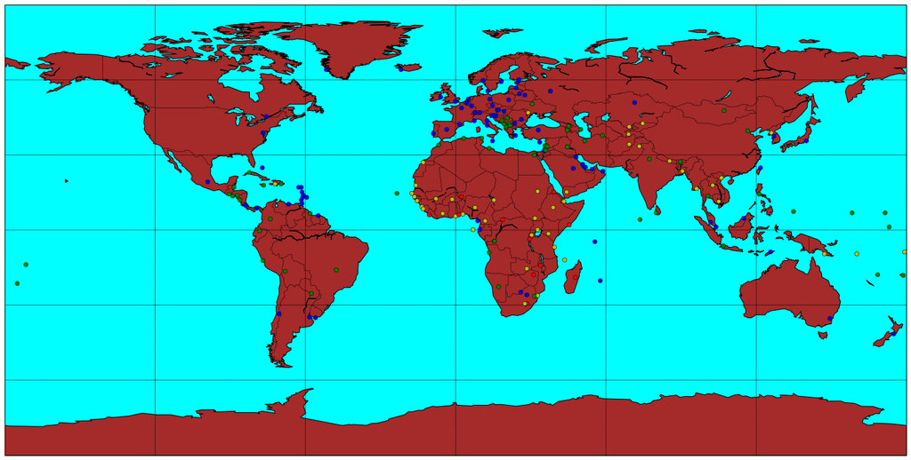

```python
fig = plt.figure(figsize=(24, 24))
map_ins = Basemap(projection="cyl", llcrnrlat=-90, urcrnrlat=90,
                       llcrnrlon=-180, urcrnrlon=180, resolution='c')
map_ins.drawcoastlines()
map_ins.fillcontinents(color="brown", lake_color="aqua")
map_ins.drawcountries()
map_ins.drawparallels(np.arange(-90., 91., 30.))
map_ins.drawmeridians(np.arange(-180., 181., 60.))
map_ins.drawmapboundary(fill_color="aqua")
colors = {"low":"ro", "median":"yo", "high":"go", "super":"bo"}

for i in range(0, lat_of_cap.shape[0]):
    xpt, ypt = map_ins(lon_of_cap[i], lat_of_cap[i])
    # According to GDP per Capita standards proposed by UNDP in 2010
    if gdp_per_capita[i]<=1005:
        map_ins.plot(xpt,ypt,colors["low"])
    elif gdp_per_capita[i]<=3975:
        map_ins.plot(xpt,ypt,colors["median"])
    elif gdp_per_capita[i]<=12275:
        map_ins.plot(xpt,ypt,colors["high"])
    else:
        map_ins.plot(xpt,ypt,colors["super"])

plt.show()
```

# 3. Parewise Correlation

```python
# Only compare columns with numerical data
data_corr = df.iloc[:,7:]
corr = data_corr.corr(method='spearman')
corr
```

|  | Population | Life Expectancy | GDP (PPP) in US $ | Area (sq km) | Land Boundaries (km) | Coastline (km) | Literacy Rate (%) | Health Expenditure/GDP | Military Expenditure/GDP | Renewable Water Resources (cu km) | Net Migration Rate/1000 Population | Labor Force | Internet Users (circa 2009) | Commercial Prime Lending Rate |
| --- | --- | --- | --- | --- | --- | --- | --- | --- | --- | --- | --- | --- | --- | --- |
| Population | 1.000000 | -0.092721 | 0.795287 | 0.774397 | 0.682970 | 0.328750 | -0.190972 | -0.044998 | 0.152012 | 0.601408 | 0.115698 | 0.988841 | 0.748998 | 0.021068 |
| Life Expectancy | -0.092721 | 1.000000 | 0.388033 | -0.254923 | -0.350614 | 0.260462 | 0.690690 | 0.273564 | -0.048574 | -0.003349 | 0.393057 | -0.041286 | 0.396612 | -0.650140 |
| GDP (PPP) in US $ | 0.795287 | 0.388033 | 1.000000 | 0.586114 | 0.470461 | 0.432650 | 0.246078 | 0.016517 | 0.131335 | 0.479363 | 0.311925 | 0.826757 | 0.918263 | -0.355958 |
| Area (sq km) | 0.774397 | -0.254923 | 0.586114 | 1.000000 | 0.830978 | 0.345343 | -0.201634 | -0.148645 | 0.163023 | 0.641663 | 0.039623 | 0.753566 | 0.515148 | 0.157181 |
| Land Boundaries (km) | 0.682970 | -0.350614 | 0.470461 | 0.830978 | 1.000000 | -0.019094 | -0.224654 | -0.159986 | 0.199450 | 0.528995 | 0.027762 | 0.656976 | 0.411493 | 0.267545 |
| Coastline (km) | 0.328750 | 0.260462 | 0.432650 | 0.345343 | -0.019094 | 1.000000 | 0.090453 | 0.048012 | 0.041670 | 0.406292 | 0.035511 | 0.352741 | 0.401673 | -0.207791 |
| Literacy Rate (%) | -0.190972 | 0.690690 | 0.246078 | -0.201634 | -0.224654 | 0.090453 | 1.000000 | 0.301307 | -0.019844 | -0.016496 | 0.208280 | -0.136193 | 0.299621 | -0.463828 |
| Health Expenditure/GDP | -0.044998 | 0.273564 | 0.016517 | -0.148645 | -0.159986 | 0.048012 | 0.301307 | 1.000000 | -0.133102 | 0.091030 | 0.122043 | -0.045945 | 0.161613 | -0.226165 |
| Military Expenditure/GDP | 0.152012 | -0.048574 | 0.131335 | 0.163023 | 0.199450 | 0.041670 | -0.019844 | -0.133102 | 1.000000 | -0.122743 | 0.125580 | 0.120507 | 0.148616 | 0.004848 |
| Renewable Water Resources (cu km) | 0.601408 | -0.003349 | 0.479363 | 0.641663 | 0.528995 | 0.406292 | -0.016496 | 0.091030 | -0.122743 | 1.000000 | -0.023747 | 0.632015 | 0.409304 | 0.158166 |
| Net Migration Rate/1000 Population | 0.115698 | 0.393057 | 0.311925 | 0.039623 | 0.027762 | 0.035511 | 0.208280 | 0.122043 | 0.125580 | -0.023747 | 1.000000 | 0.129944 | 0.253070 | -0.366704 |
| Labor Force | 0.988841 | -0.041286 | 0.826757 | 0.753566 | 0.656976 | 0.352741 | -0.136193 | -0.045945 | 0.120507 | 0.632015 | 0.129944 | 1.000000 | 0.771226 | -0.010896 |
| Internet Users (circa 2009) | 0.748998 | 0.396612 | 0.918263 | 0.515148 | 0.411493 | 0.401673 | 0.299621 | 0.161613 | 0.148616 | 0.409304 | 0.253070 | 0.771226 | 1.000000 | -0.320439 |
| Commercial Prime Lending Rate | 0.021068 | -0.650140 | -0.355958 | 0.157181 | 0.267545 | -0.207791 | -0.463828 | -0.226165 | 0.004848 | 0.158166 | -0.366704 | -0.010896 | -0.320439 | 1.000000 |

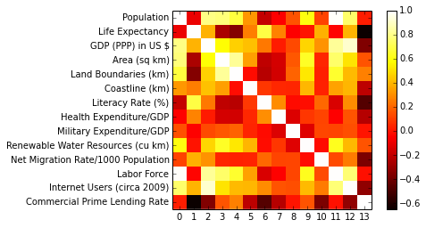

```python
# Color the data to make them more visible
plt.imshow(corr, cmap='hot', interpolation='none')
plt.colorbar()
plt.xticks(range(len(corr)))
plt.yticks(range(len(corr)), corr.columns);
```

[output not shown]

# 4. Linear Regression

```python
y = gdp_per_capita
x1 = area
x2 = internet_user_rate
x3 = literacy_rate

matrix = np.vstack([x1, x2, x3, y, country_name]).T
temp = np.vstack([x1, x2, x3, y]).T
matrix = matrix[~np.isnan(temp).any(axis=1)]

x = matrix[:,0:3] #formed by x1, x2, x3
y = matrix[:,3:4] #formed by y

reg = linear_model.LinearRegression()
reg.fit(x, y)
predict_y = reg.decision_function(x)
#print(predict_y)

residul = predict_y - y
result = {"Country Name":matrix[:,4], "Actual GDP per Capita":matrix[:,3],
          "Predicted GDP per Capita":predict_y[:,0]}
result = pd.DataFrame(result)
result = result[["Country Name", "Actual GDP per Capita", "Predicted GDP per Capita"]]
print result.to_string()
```

```
                          Country Name Actual GDP per Capita Predicted GDP per Capita
0                          Afghanistan              1423.506                 47.50167
1                              Albania              9383.457                 23564.53
2                              Algeria              7335.035                   7234.7
3                              Andorra              37012.33                 41053.62
4                               Angola              6904.823                 2649.049
5                  Antigua and Barbuda              17635.14                 37423.84
6                            Argentina              17920.07                  18400.5
7                              Armenia              6733.906                 6058.639
8                            Australia              44353.87                 37631.34
9                              Austria              43900.92                 39081.38
10                          Azerbaijan               10602.7                 14942.12
11                        Bahamas, The              35421.99                 20047.43
12                             Bahrain              26603.98                 18007.44
13                          Bangladesh              1952.121                 423.8918
```

[output cut: 174 more lines]

```python
print "The coutry having the highest predicted GDP per Capita is", result["Country Name"].ix[np.argmax(predict_y)], \
      ", whose predicted GDP per Capita is", result["Predicted GDP per Capita"].ix[np.argmax(predict_y)], \
      " and actual GDP per Capita is", result["Actual GDP per Capita"].ix[np.argmax(predict_y)]
print "The coutry having the lowest predicted GDP per Capita is", result["Country Name"].ix[np.argmin(predict_y)], \
      ", whose predicted GDP per Capita is", result["Predicted GDP per Capita"].ix[np.argmin(predict_y)], \
      " and actual GDP per Capita is", result["Actual GDP per Capita"].ix[np.argmin(predict_y)]
```

```
The coutry having the highest predicted GDP per Capita is Iceland , whose predicted GDP per Capita is 49058.3213113  and actual GDP per Capita is 41310.7253483
The coutry having the lowest predicted GDP per Capita is Niger , whose predicted GDP per Capita is -1071.96825499  and actual GDP per Capita is 800.404347329
```

The max and min predicted GDP per Capita basically match the actual ones, based on our common sense. But, the predicted GDP per Capita for the min is a negative value, which reveals the discrepancy of the raw data.

# 5. Scoring Function

```python
welfare = pd.DataFrame()
welfare["GDP/Capita"] = gdp_per_capita
welfare["Life Expectancy"] = life_expectancy
welfare["Health Exp/GDP"] = health_exp_over_gdp
welfare["Literacy Rate"] = literacy_rate
welfare["Internet User Rate"] = internet_user_rate
weights = [4.0, 2.0, 2.0, 1.0, 1.0]

welfare = welfare.fillna(welfare.median(0, True))
welfare = welfare.div(welfare.sum(axis=0), axis=1) #normalize data
#welfare

scores = weights[0] * welfare["GDP/Capita"] + weights[1] * welfare["Life Expectancy"] + \
    weights[2] * welfare["Health Exp/GDP"] + weights[3] * welfare["Literacy Rate"] + \
    weights[4] * welfare["Internet User Rate"]
result = df.loc[:,["Country Name"]]
result["Score"] = scores
print result.to_string()
```

```
                          Country Name     Score
0                          Afghanistan  0.025214
1                              Albania  0.045127
2                              Algeria  0.032193
3                              Andorra  0.087808
4                               Angola  0.026406
5                  Antigua and Barbuda  0.059466
6                            Argentina  0.056528
7                              Armenia  0.032415
8                            Australia  0.098067
9                              Austria  0.100249
10                          Azerbaijan  0.041318
11                        Bahamas, The  0.077581
12                             Bahrain  0.061095
13                          Bangladesh  0.021483
```

[output cut: 183 more lines]

```python
print "The coutry having the highest score is", result["Country Name"].ix[np.argmax(scores)]
print "The coutry having the lowest score is", result["Country Name"].ix[np.argmin(scores)]
```

```
The coutry having the highest score is Monaco
The coutry having the lowest score is Central African Republic
```

# 6. Distance Function

```python
df_transposed = df.iloc[:,7:]
df_transposed.drop("Net Migration Rate/1000 Population", axis=1, inplace=True)
    #don't consider this col with both positive and negative values for now
df_transposed.fillna(df_transposed.median(0, True), inplace=True)
df_transposed = df_transposed.div(df_transposed.sum(axis=0), axis=1)
df_transposed = df_transposed.T #actual transposing step
df_transposed.columns = country_name
#df_transposed

#naive solution using cosine of two vectors cos0=1 means closest
diff_distance = pd.DataFrame(data=np.nan, index=country_name, columns=country_name)
for i in range(0, country_name.shape[0]):
    for j in range(0, country_name.shape[0]):
        diff_distance.ix[i, j] = cosine(df_transposed.ix[:,i], df_transposed.ix[:,j])
np.fill_diagonal(diff_distance.values, np.nan)
diff_distance
```

|  | Afghanistan | Albania | Algeria | Andorra | Angola | Antigua and Barbuda | Argentina | Armenia | Australia | Austria | ... | United States | Uruguay | Uzbekistan | Vanuatu | Venezuela | Vietnam | Western Sahara | Yemen | Zambia | Zimbabwe |
| --- | --- | --- | --- | --- | --- | --- | --- | --- | --- | --- | --- | --- | --- | --- | --- | --- | --- | --- | --- | --- | --- |
| Afghanistan | NaN | 0.307218 | 0.156055 | 0.369770 | 0.075422 | 0.379058 | 0.328460 | 0.174432 | 0.680936 | 0.357396 | ... | 0.747544 | 0.206802 | 0.162683 | 0.409452 | 0.450546 | 0.423649 | 0.199570 | 0.119743 | 0.104853 | 0.134152 |
| Albania | 0.307218 | NaN | 0.465768 | 0.010055 | 0.326816 | 0.013578 | 0.554152 | 0.107124 | 0.772672 | 0.174616 | ... | 0.839176 | 0.024585 | 0.312076 | 0.063472 | 0.490414 | 0.518326 | 0.046059 | 0.181308 | 0.328544 | 0.166109 |
| Algeria | 0.156055 | 0.465768 | NaN | 0.546142 | 0.058151 | 0.544996 | 0.182357 | 0.377732 | 0.328586 | 0.433941 | ... | 0.553863 | 0.364995 | 0.207324 | 0.528683 | 0.453513 | 0.454678 | 0.316190 | 0.252325 | 0.139247 | 0.315876 |
| Andorra | 0.369770 | 0.010055 | 0.546142 | NaN | 0.399514 | 0.007617 | 0.638411 | 0.131946 | 0.818120 | 0.215825 | ... | 0.911691 | 0.044324 | 0.402680 | 0.071697 | 0.533075 | 0.590732 | 0.078487 | 0.224975 | 0.403401 | 0.206178 |
| Angola | 0.075422 | 0.326816 | 0.058151 | 0.399514 | NaN | 0.400713 | 0.177148 | 0.219773 | 0.435441 | 0.395555 | ... | 0.643853 | 0.219757 | 0.147219 | 0.381707 | 0.331289 | 0.393206 | 0.185000 | 0.132524 | 0.075336 | 0.151514 |
| Antigua and Barbuda | 0.379058 | 0.013578 | 0.544996 | 0.007617 | 0.400713 | NaN | 0.679276 | 0.111261 | 0.823001 | 0.254313 | ... | 0.933319 | 0.062232 | 0.414563 | 0.068014 | 0.598638 | 0.634370 | 0.086566 | 0.203219 | 0.424305 | 0.190226 |
| Argentina | 0.328460 | 0.554152 | 0.182357 | 0.638411 | 0.177148 | 0.679276 | NaN | 0.609171 | 0.315688 | 0.372298 | ... | 0.380351 | 0.411866 | 0.201911 | 0.616087 | 0.152207 | 0.276903 | 0.370159 | 0.455922 | 0.149826 | 0.426579 |
| Armenia | 0.174432 | 0.107124 | 0.377732 | 0.131946 | 0.219773 | 0.111261 | 0.609171 | NaN | 0.837963 | 0.376961 | ... | 0.896662 | 0.100569 | 0.336334 | 0.158048 | 0.566826 | 0.575500 | 0.123647 | 0.070878 | 0.320690 | 0.090473 |
| Australia | 0.680936 | 0.772672 | 0.328586 | 0.818120 | 0.435441 | 0.823001 | 0.315688 | 0.837963 | NaN | 0.721494 | ... | 0.486242 | 0.685165 | 0.696993 | 0.660440 | 0.536902 | 0.639514 | 0.628629 | 0.603480 | 0.586896 | 0.733923 |
| Austria | 0.357396 | 0.174616 | 0.433941 | 0.215825 | 0.395555 | 0.254313 | 0.372298 | 0.376961 | 0.721494 | NaN | ... | 0.506021 | 0.156779 | 0.224943 | 0.296727 | 0.424424 | 0.392088 | 0.170802 | 0.415952 | 0.284114 | 0.385768 |
| Azerbaijan | 0.117537 | 0.134668 | 0.312005 | 0.174246 | 0.171141 | 0.159434 | 0.529194 | 0.012209 | 0.802278 | 0.339740 | ... | 0.792964 | 0.106193 | 0.275263 | 0.197867 | 0.512347 | 0.482923 | 0.131579 | 0.057301 | 0.269557 | 0.088709 |
| Bahamas, The | 0.442709 | 0.101069 | 0.564145 | 0.107928 | 0.451600 | 0.108908 | 0.652958 | 0.246011 | 0.636967 | 0.252280 | ... | 0.882815 | 0.131556 | 0.479135 | 0.037308 | 0.619355 | 0.614561 | 0.135073 | 0.290342 | 0.490043 | 0.357465 |
| Bahrain | 0.298352 | 0.097435 | 0.449526 | 0.105260 | 0.339089 | 0.089375 | 0.723956 | 0.052008 | 0.827058 | 0.348424 | ... | 0.895512 | 0.126083 | 0.451268 | 0.106185 | 0.651848 | 0.619481 | 0.169893 | 0.162249 | 0.462089 | 0.243983 |
| Bangladesh | 0.540741 | 0.682605 | 0.596480 | 0.727489 | 0.519820 | 0.775386 | 0.421456 | 0.718893 | 0.796693 | 0.610933 | ... | 0.588643 | 0.598556 | 0.422096 | 0.727922 | 0.268943 | 0.113480 | 0.673317 | 0.582476 | 0.522311 | 0.628007 |
| Barbados | 0.378116 | 0.017089 | 0.551548 | 0.007330 | 0.424116 | 0.009462 | 0.681229 | 0.142947 | 0.820348 | 0.208218 | ... | 0.922106 | 0.061037 | 0.418819 | 0.079812 | 0.611711 | 0.631584 | 0.088476 | 0.236048 | 0.426329 | 0.228371 |
| Belarus | 0.186332 | 0.117773 | 0.275316 | 0.178851 | 0.168545 | 0.189015 | 0.274857 | 0.191308 | 0.711331 | 0.122814 | ... | 0.664706 | 0.084292 | 0.066332 | 0.241221 | 0.348122 | 0.375564 | 0.061437 | 0.216970 | 0.096688 | 0.143583 |
| Belgium | 0.403392 | 0.162912 | 0.482234 | 0.198436 | 0.452555 | 0.223562 | 0.468101 | 0.356577 | 0.728221 | 0.024128 | ... | 0.459853 | 0.171560 | 0.304036 | 0.275532 | 0.501774 | 0.402185 | 0.204172 | 0.383583 | 0.388120 | 0.390043 |
| Belize | 0.332863 | 0.018958 | 0.518026 | 0.020980 | 0.351224 | 0.018149 | 0.589688 | 0.119389 | 0.795583 | 0.245367 | ... | 0.912353 | 0.046770 | 0.353344 | 0.087856 | 0.523907 | 0.595733 | 0.060193 | 0.177536 | 0.346624 | 0.129704 |
| Benin | 0.143047 | 0.100435 | 0.315001 | 0.143379 | 0.176418 | 0.151500 | 0.366225 | 0.143047 | 0.754421 | 0.209864 | ... | 0.807499 | 0.071942 | 0.128014 | 0.212456 | 0.404092 | 0.426542 | 0.065586 | 0.137138 | 0.126560 | 0.078224 |
| Bhutan | 0.237547 | 0.066757 | 0.447443 | 0.079847 | 0.257408 | 0.080260 | 0.514426 | 0.077352 | 0.812441 | 0.313369 | ... | 0.885139 | 0.058680 | 0.308359 | 0.144491 | 0.429565 | 0.535070 | 0.081853 | 0.119428 | 0.278031 | 0.066653 |
| Bolivia | 0.254200 | 0.414916 | 0.240624 | 0.471409 | 0.151174 | 0.523165 | 0.091406 | 0.442584 | 0.542941 | 0.360374 | ... | 0.653241 | 0.279235 | 0.174787 | 0.501641 | 0.115709 | 0.329544 | 0.257150 | 0.405468 | 0.096206 | 0.325133 |
| Bosnia and Herzegovina | 0.279459 | 0.040398 | 0.452036 | 0.052489 | 0.345320 | 0.075977 | 0.509503 | 0.193142 | 0.784451 | 0.090964 | ... | 0.826858 | 0.043343 | 0.266325 | 0.142309 | 0.502641 | 0.514854 | 0.054927 | 0.263341 | 0.273541 | 0.227385 |
| Botswana | 0.085275 | 0.200781 | 0.146030 | 0.261474 | 0.064576 | 0.262219 | 0.277828 | 0.155352 | 0.620858 | 0.265285 | ... | 0.785457 | 0.131824 | 0.108831 | 0.305049 | 0.435107 | 0.518754 | 0.083146 | 0.167917 | 0.051881 | 0.119700 |
| Brazil | 0.671926 | 0.803375 | 0.561043 | 0.836000 | 0.525751 | 0.913815 | 0.238919 | 0.868361 | 0.493313 | 0.653288 | ... | 0.409269 | 0.652938 | 0.604229 | 0.813609 | 0.083870 | 0.234672 | 0.710884 | 0.738297 | 0.559805 | 0.755647 |
| Brunei | 0.330254 | 0.081299 | 0.450048 | 0.093059 | 0.340251 | 0.077222 | 0.693343 | 0.067329 | 0.823650 | 0.324266 | ... | 0.901882 | 0.118440 | 0.417244 | 0.089090 | 0.624631 | 0.615645 | 0.150703 | 0.193998 | 0.440396 | 0.256677 |
| Bulgaria | 0.229479 | 0.027677 | 0.364317 | 0.062380 | 0.256330 | 0.070930 | 0.423803 | 0.137606 | 0.719973 | 0.090778 | ... | 0.710426 | 0.027212 | 0.192337 | 0.126209 | 0.443317 | 0.434641 | 0.030930 | 0.179244 | 0.219741 | 0.150868 |
| Burkina Faso | 0.068896 | 0.228053 | 0.222187 | 0.289155 | 0.127161 | 0.304672 | 0.286362 | 0.228245 | 0.713376 | 0.238538 | ... | 0.760979 | 0.158330 | 0.074223 | 0.363804 | 0.415902 | 0.396038 | 0.135846 | 0.173938 | 0.056972 | 0.121638 |
| Burundi | 0.160581 | 0.064909 | 0.409801 | 0.078830 | 0.256238 | 0.080171 | 0.564624 | 0.064927 | 0.816337 | 0.255599 | ... | 0.869483 | 0.052774 | 0.296192 | 0.158301 | 0.529254 | 0.504032 | 0.083190 | 0.086055 | 0.281230 | 0.080977 |
| Cabo Verde | 0.490581 | 0.046236 | 0.620172 | 0.042737 | 0.468363 | 0.034698 | 0.652774 | 0.218201 | 0.773176 | 0.272191 | ... | 0.925055 | 0.106750 | 0.433079 | 0.080206 | 0.577790 | 0.640461 | 0.112540 | 0.276977 | 0.455930 | 0.235852 |
| Cambodia | 0.262069 | 0.222994 | 0.414838 | 0.247869 | 0.232613 | 0.298319 | 0.272152 | 0.275535 | 0.698646 | 0.304385 | ... | 0.703404 | 0.132398 | 0.252486 | 0.283952 | 0.100442 | 0.236330 | 0.179297 | 0.266132 | 0.224577 | 0.223562 |
| ... | ... | ... | ... | ... | ... | ... | ... | ... | ... | ... | ... | ... | ... | ... | ... | ... | ... | ... | ... | ... | ... |
| Swaziland | 0.209811 | 0.091265 | 0.432637 | 0.096057 | 0.305299 | 0.093145 | 0.673252 | 0.053625 | 0.829143 | 0.295054 | ... | 0.908669 | 0.087369 | 0.407111 | 0.144800 | 0.626722 | 0.606736 | 0.123686 | 0.137029 | 0.381632 | 0.180191 |
| Sweden | 0.348775 | 0.207782 | 0.329822 | 0.263749 | 0.297698 | 0.297265 | 0.241532 | 0.383187 | 0.436025 | 0.072449 | ... | 0.389055 | 0.160652 | 0.250518 | 0.230726 | 0.298466 | 0.290515 | 0.165118 | 0.339053 | 0.281955 | 0.379789 |
| Switzerland | 0.399741 | 0.160160 | 0.482213 | 0.192646 | 0.443529 | 0.227323 | 0.433957 | 0.377909 | 0.735290 | 0.006729 | ... | 0.509806 | 0.159786 | 0.273758 | 0.277558 | 0.466423 | 0.408797 | 0.184541 | 0.416511 | 0.345002 | 0.398370 |
| Syria | 0.175732 | 0.097639 | 0.263035 | 0.161411 | 0.166562 | 0.156267 | 0.331722 | 0.135346 | 0.692385 | 0.168472 | ... | 0.632416 | 0.084069 | 0.104695 | 0.203244 | 0.386270 | 0.332245 | 0.078049 | 0.129095 | 0.157432 | 0.108175 |
| Taiwan | 0.579917 | 0.387708 | 0.552993 | 0.442554 | 0.566286 | 0.452210 | 0.505217 | 0.516627 | 0.649608 | 0.203619 | ... | 0.186501 | 0.395503 | 0.474490 | 0.433837 | 0.512478 | 0.329425 | 0.456963 | 0.478039 | 0.613079 | 0.571107 |
| Tajikistan | 0.192253 | 0.145692 | 0.370145 | 0.192966 | 0.196328 | 0.185398 | 0.386953 | 0.151986 | 0.807157 | 0.294429 | ... | 0.852029 | 0.115970 | 0.154091 | 0.273938 | 0.428334 | 0.512857 | 0.083973 | 0.164050 | 0.140953 | 0.044819 |
| Tanzania | 0.201042 | 0.353941 | 0.188411 | 0.423809 | 0.148209 | 0.436992 | 0.193714 | 0.401455 | 0.485006 | 0.333317 | ... | 0.610462 | 0.278891 | 0.108096 | 0.449315 | 0.335189 | 0.240493 | 0.255217 | 0.240166 | 0.128499 | 0.240876 |
| Thailand | 0.380899 | 0.500567 | 0.342535 | 0.595813 | 0.319045 | 0.625000 | 0.190172 | 0.562953 | 0.566555 | 0.302606 | ... | 0.276282 | 0.418966 | 0.189519 | 0.558578 | 0.225840 | 0.048481 | 0.440906 | 0.431466 | 0.311247 | 0.477564 |
| Timor-Leste | 0.219814 | 0.091626 | 0.441244 | 0.097799 | 0.277634 | 0.090313 | 0.642144 | 0.027736 | 0.788770 | 0.369408 | ... | 0.883476 | 0.085634 | 0.429025 | 0.109205 | 0.543976 | 0.569993 | 0.133580 | 0.080187 | 0.395522 | 0.130413 |
| Togo | 0.152580 | 0.054407 | 0.372854 | 0.078626 | 0.236108 | 0.091229 | 0.471347 | 0.111381 | 0.794293 | 0.166012 | ... | 0.851509 | 0.035898 | 0.206684 | 0.163452 | 0.483810 | 0.489365 | 0.044517 | 0.142075 | 0.194335 | 0.104009 |
| Tonga | 0.379621 | 0.014557 | 0.544664 | 0.008858 | 0.382065 | 0.006302 | 0.639872 | 0.108169 | 0.798728 | 0.267409 | ... | 0.913607 | 0.051502 | 0.413756 | 0.053470 | 0.521414 | 0.587679 | 0.082110 | 0.195173 | 0.417404 | 0.182739 |
| Trinidad and Tobago | 0.380653 | 0.012782 | 0.524699 | 0.011451 | 0.400151 | 0.007072 | 0.663725 | 0.122607 | 0.794207 | 0.215581 | ... | 0.885528 | 0.060858 | 0.403639 | 0.055158 | 0.591864 | 0.599865 | 0.087374 | 0.218573 | 0.427587 | 0.229026 |
| Tunisia | 0.210302 | 0.045134 | 0.310637 | 0.089720 | 0.224709 | 0.093426 | 0.402513 | 0.137196 | 0.636015 | 0.109557 | ... | 0.659967 | 0.043512 | 0.189600 | 0.104926 | 0.444710 | 0.388533 | 0.048716 | 0.144099 | 0.227230 | 0.167327 |
| Turkey | 0.427594 | 0.464352 | 0.375663 | 0.553297 | 0.366650 | 0.555243 | 0.286580 | 0.515954 | 0.452376 | 0.329111 | ... | 0.179691 | 0.414005 | 0.338383 | 0.484070 | 0.355046 | 0.170160 | 0.436946 | 0.338767 | 0.440797 | 0.431571 |
| Turkmenistan | 0.170314 | 0.190129 | 0.188584 | 0.255289 | 0.102286 | 0.252613 | 0.260844 | 0.195887 | 0.641003 | 0.254174 | ... | 0.772645 | 0.144536 | 0.081893 | 0.292270 | 0.400119 | 0.493727 | 0.089396 | 0.219945 | 0.063547 | 0.147658 |
| Tuvalu | 0.404630 | 0.128194 | 0.638930 | 0.104408 | 0.523506 | 0.136847 | 0.679057 | 0.304459 | 0.825855 | 0.199348 | ... | 0.900250 | 0.132785 | 0.494445 | 0.225956 | 0.613323 | 0.636079 | 0.170027 | 0.349780 | 0.462290 | 0.319745 |
| Uganda | 0.198214 | 0.197975 | 0.378605 | 0.242009 | 0.236203 | 0.245505 | 0.380292 | 0.232930 | 0.741061 | 0.298816 | ... | 0.709280 | 0.160328 | 0.180391 | 0.338060 | 0.389480 | 0.313332 | 0.170928 | 0.140129 | 0.208315 | 0.083921 |
| Ukraine | 0.126397 | 0.262883 | 0.180039 | 0.350247 | 0.103418 | 0.357634 | 0.184418 | 0.258892 | 0.545298 | 0.226428 | ... | 0.483059 | 0.186090 | 0.066931 | 0.339575 | 0.286851 | 0.184151 | 0.175719 | 0.156112 | 0.113202 | 0.172573 |
| United Arab Emirates | 0.207889 | 0.217006 | 0.346551 | 0.255192 | 0.251274 | 0.234069 | 0.627231 | 0.066511 | 0.752691 | 0.403153 | ... | 0.719701 | 0.200222 | 0.414885 | 0.212175 | 0.610864 | 0.531240 | 0.243073 | 0.118418 | 0.424474 | 0.237493 |
| United Kingdom | 0.703708 | 0.649894 | 0.624656 | 0.727918 | 0.661511 | 0.730423 | 0.505436 | 0.734132 | 0.550253 | 0.409020 | ... | 0.109529 | 0.627987 | 0.603771 | 0.627113 | 0.559207 | 0.342543 | 0.666585 | 0.606364 | 0.739575 | 0.732609 |
| United States | 0.747544 | 0.839176 | 0.553863 | 0.911691 | 0.643853 | 0.933319 | 0.380351 | 0.896662 | 0.486242 | 0.506021 | ... | NaN | 0.767055 | 0.637805 | 0.880773 | 0.471322 | 0.379899 | 0.808858 | 0.742355 | 0.712747 | 0.825813 |
| Uruguay | 0.206802 | 0.024585 | 0.364995 | 0.044324 | 0.219757 | 0.062232 | 0.411866 | 0.100569 | 0.685165 | 0.156779 | ... | 0.767055 | NaN | 0.244258 | 0.091993 | 0.358837 | 0.430261 | 0.019907 | 0.142705 | 0.224214 | 0.124095 |
| Uzbekistan | 0.162683 | 0.312076 | 0.207324 | 0.402680 | 0.147219 | 0.414563 | 0.201911 | 0.336334 | 0.696993 | 0.224943 | ... | 0.637805 | 0.244258 | NaN | 0.448721 | 0.362850 | 0.295955 | 0.199510 | 0.297556 | 0.051224 | 0.233364 |
| Vanuatu | 0.409452 | 0.063472 | 0.528683 | 0.071697 | 0.381707 | 0.068014 | 0.616087 | 0.158048 | 0.660440 | 0.296727 | ... | 0.880773 | 0.091993 | 0.448721 | NaN | 0.518562 | 0.561515 | 0.110081 | 0.217557 | 0.457963 | 0.276321 |
| Venezuela | 0.450546 | 0.490414 | 0.453513 | 0.533075 | 0.331289 | 0.598638 | 0.152207 | 0.566826 | 0.536902 | 0.424424 | ... | 0.471322 | 0.358837 | 0.362850 | 0.518562 | NaN | 0.180118 | 0.398540 | 0.487071 | 0.330244 | 0.455255 |
| Vietnam | 0.423649 | 0.518326 | 0.454678 | 0.590732 | 0.393206 | 0.634370 | 0.276903 | 0.575500 | 0.639514 | 0.392088 | ... | 0.379899 | 0.430261 | 0.295955 | 0.561515 | 0.180118 | NaN | 0.488077 | 0.445246 | 0.405731 | 0.505512 |
| Western Sahara | 0.199570 | 0.046059 | 0.316190 | 0.078487 | 0.185000 | 0.086566 | 0.370159 | 0.123647 | 0.628629 | 0.170802 | ... | 0.808858 | 0.019907 | 0.199510 | 0.110081 | 0.398540 | 0.488077 | NaN | 0.155292 | 0.168048 | 0.114907 |
| Yemen | 0.119743 | 0.181308 | 0.252325 | 0.224975 | 0.132524 | 0.203219 | 0.455922 | 0.070878 | 0.603480 | 0.415952 | ... | 0.742355 | 0.142705 | 0.297556 | 0.217557 | 0.487071 | 0.445246 | 0.155292 | NaN | 0.266855 | 0.058286 |
| Zambia | 0.104853 | 0.328544 | 0.139247 | 0.403401 | 0.075336 | 0.424305 | 0.149826 | 0.320690 | 0.586896 | 0.284114 | ... | 0.712747 | 0.224214 | 0.051224 | 0.457963 | 0.330244 | 0.405731 | 0.168048 | 0.266855 | NaN | 0.189531 |
| Zimbabwe | 0.134152 | 0.166109 | 0.315876 | 0.206178 | 0.151514 | 0.190226 | 0.426579 | 0.090473 | 0.733923 | 0.385768 | ... | 0.825813 | 0.124095 | 0.233364 | 0.276321 | 0.455255 | 0.505512 | 0.114907 | 0.058286 | 0.189531 | NaN |

197 rows × 197 columns

```python
result = pd.DataFrame(columns=["Most Distant Nation", "Most Close Nation"])
result["Most Distant Nation"] = diff_distance.idxmax(axis=0, skipna=True)
result["Most Close Nation"] = diff_distance.idxmin(axis=0, skipna=True)
print result.to_string()
```

```
                                     Most Distant Nation                 Most Close Nation
Afghanistan                                       Canada                      Burkina Faso
Albania                                           Canada                            Kosovo
Algeria                                      Philippines                            Angola
Andorra                                            China                     Liechtenstein
Angola                                             Japan                           Namibia
Antigua and Barbuda                                China                           Comoros
Argentina                                        Bahrain                           Bolivia
Armenia                                           Canada                        Azerbaijan
Australia                                    Gambia, The                            Russia
Austria                                           Canada                       Switzerland
Azerbaijan                                        Canada                           Armenia
Bahamas, The                                       China                           Estonia
Bahrain                                           Canada                            Brunei
Bangladesh                                     Greenland                           Vietnam
Barbados                                           China                          Maldives
Belarus                                           Canada                             Syria
Belgium                                           Canada                       Switzerland
Belize                                             China                       El Salvador
Benin                                             Canada                           Senegal
Bhutan                                             China                           Georgia
Bolivia                                            Japan                          Cameroon
Bosnia and Herzegovina                            Canada                          Slovenia
Botswana                                           Japan                           Namibia
Brazil                                             Malta                          Colombia
Brunei                                             China                           Bahrain
Bulgaria                                          Canada                           Tunisia
Burkina Faso                                      Canada                           Senegal
Burundi                                           Canada                           Georgia
Cabo Verde                                         China                         Mauritius
Cambodia                                       Greenland                           Ecuador
Cameroon                                       Greenland                        Mozambique
Canada                                       Gambia, The                         Greenland
Central African Republic                           Japan                            Zambia
Chad                                               Japan                        Mauritania
Chile                                              India                         Venezuela
China                              Saint Kitts and Nevis                           Nigeria
Colombia                                       Greenland                              Peru
Comoros                                            China               Antigua and Barbuda
Congo, Democratic Republic of the              Greenland                             Burma
```

[output cut: 143 more lines]

```
Tuvalu                                             China                  Marshall Islands
Uganda                                            Canada                           Senegal
Ukraine                                           Canada                             Kenya
United Arab Emirates                              Canada                            Israel
United Kingdom                                  Mongolia                             Japan
United States                                Gambia, The                           Germany
Uruguay                                            India                            Serbia
Uzbekistan                                        Canada                            Zambia
Vanuatu                                            China                              Fiji
Venezuela                                      Greenland                              Peru
Vietnam                                        Greenland                          Thailand
Western Sahara                                     India                          Suriname
Yemen                                             Canada                        Azerbaijan
Zambia                                             Japan          Central African Republic
Zimbabwe                                          Canada                        Kyrgyzstan
```